# Documentation

Joris Baiutti & Claudio Polo

June 4, 2018

### Load stuff

```r
library(Quandl)
library(ggplot2)
```

Api key: 1ywuwWFWbtaziA2GcaRU

```r
Quandl.api_key('1ywuwWFWbtaziA2GcaRU')
```

*Data* https://www.quandl.com/data/EURONEXT-Euronext-Stock-Exchange

## Introduction

This document goes through a Monte Carlo Simulation of Deutsche Telekom, Volkswagen and Airbus closing stock prices.

## Calculation of standard deviation and mean

For the standard deviation we collect the percentuel rate values. These values can be optained directly with quandle. Then we can calculate standard deviation and mean of those rate values.

### Deutsche Telekom

#### Percentual rates

In this graph we can see the percentual daily rates over a year.

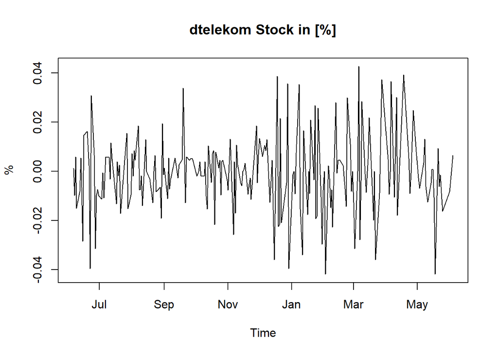

```r
dtelekomclosing = Quandl('EURONEXT/DTEL',start_date='2017-06-04', type='zoo',end_date='2018-06-04',transform = "rdiff")[,"Last"]
plot(dtelekomclosing,ylab="%",xlab="Time",main="dtelekom Stock in [%]")
```

```r
dtelekomsd = sd(dtelekomclosing)
dtelekommean = mean(dtelekomclosing)
```

#### Arithmetic mean and standard deviation

```r
dtelekommatrix = matrix(c(dtelekomsd,dtelekommean),ncol=2,byrow=TRUE)
colnames(dtelekommatrix) = c("Standard deviation","mean")
print.table(dtelekommatrix)
```

```
##      Standard deviation         mean
## [1,]        0.015379015 -0.001124455
```

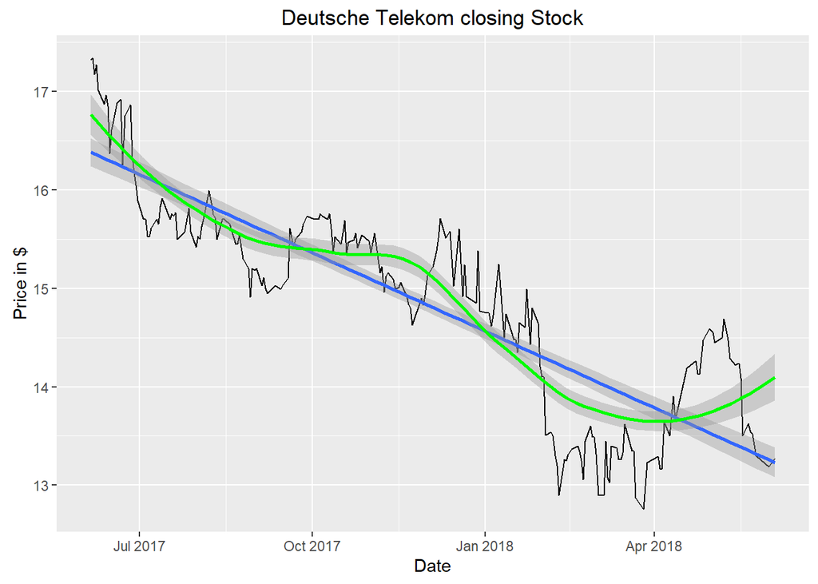

```r
dtelekom = Quandl('EURONEXT/DTEL', start_date='2017-06-04', end_date='2018-06-04')
ggplot(dtelekom, aes(Date, Last,)) + geom_line() + geom_smooth(method = "lm") + geom_smooth(method = "loess", color="Green") + labs(title="Deutsche Telekom closing Stock", y="Price in $", caption="Source: EURONEXT")
```

#### Brownian Motion

```r
nSim = 1000
nDays = 250
S0 = head(Quandl('EURONEXT/DTEL', start_date='2017-06-04', end_date='2018-06-04'), n=1)
S0 = S0$Last
S = matrix(0,nrow=nDays,ncol=nSim)
```

```r
for (i in 1:nSim) {
  SVec = rep(0, nDays)
  SVec[1] = S0
  for(j in 2:nDays) {
    pastDay = SVec[j-1]
    DeltaS = dtelekommean*pastDay + dtelekomsd*pastDay*rnorm(1)
    SVec[j] = pastDay+DeltaS
  }
  S[,i] = SVec
}
```

Calculation of SimulationS bOundaries

```r
mean = dtelekommean * nDays
sigma = dtelekomsd * sqrt(nDays)
t = seq(from=0,to=1,length.out=nDays)
meanBnd = vector(length = nDays); upBnd = vector(length = nDays); loBnd = vector(length = nDays); test = vector(length = nDays)
for(i in 0:nDays){
  meanBnd[i] = S0*exp((( mean-sigma^2/2 ))*t[i])
  upBnd[i] = S0*exp((( mean-sigma^2/2 ))*t[i] + (sigma * 2.5 * sqrt(t[i])))
  loBnd[i] = S0*exp((( mean-sigma^2/2 ))*t[i] + (sigma * -2.5 * sqrt(t[i])))
}
```

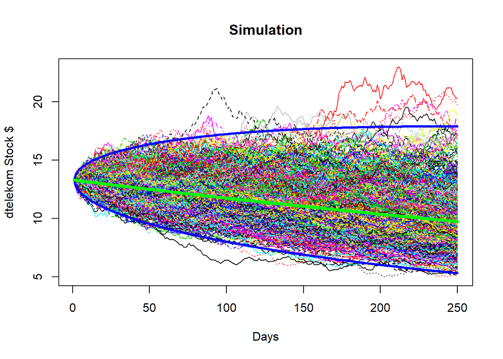

```r
matplot(S,type='l',col=1:100,ylab='dtelekom Stock $',xlab='Days',main='Simulation')
matlines(loBnd,lwd=3,col="blue")
matlines(upBnd,lwd=3,col="blue")
matlines(meanBnd,lwd=4,col="green")
```

Calculation of the Longnormal Distribution

```r
lnMean = S0*exp(dtelekommean*nDays)
lnSD = S0*exp(dtelekommean*nDays)*sqrt(exp((dtelekomsd^2)*nDays)-1)
```

Mean over a year over all Simulations

```r
cat('Mean',mean(S[nDays,]))
```

```
## Mean 10.00496
```

Standard deviation over a year over all Simulations

```r
cat('Standard Deviation',lnSD,sd(S[nDays,]))
```

```
## Standard Deviation 2.473423 2.407046
```

Presentation of the longnormal distribution of theoretical density and empirical density

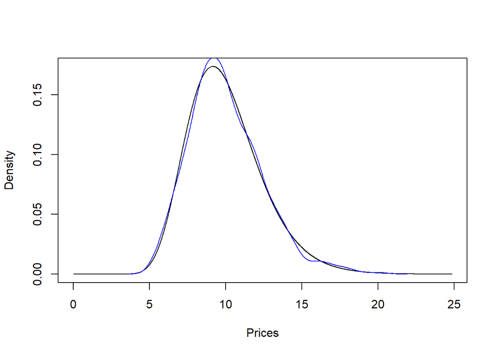

```r
meanOfLog = log(S0) + (dtelekommean-(dtelekomsd^2)/2)*nDays
sdOfLog = dtelekomsd*sqrt(nDays)
priceGrid = seq(0,lnMean+6*lnSD,length=10000)
theoreticalDens = dlnorm(priceGrid,meanOfLog,sdOfLog)
empiricalDens = density(S[nDays,])

plot(priceGrid,theoreticalDens,type='l',xlab='Prices',ylab='Density')
lines(empiricalDens,col='blue')
```

### Volkswagen

#### Percentual rates

In this graph we can see the percentual daily rates over a year.

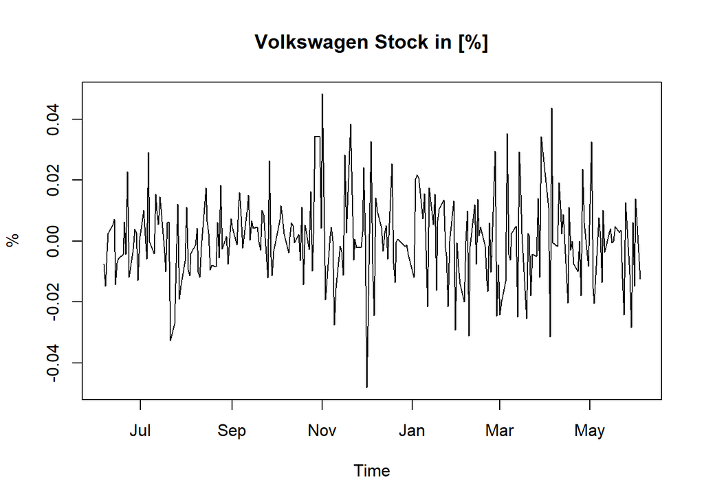

```r
volkswagenclosing = Quandl('EURONEXT/VWA',start_date='2017-06-04', type='zoo',end_date='2018-06-04',transform = "rdiff")[,"Last"]
plot(volkswagenclosing,ylab="%",xlab="Time",main="Volkswagen Stock in [%]")
```

```r
volkswagensd = sd(volkswagenclosing)
volkswagenmean = mean(volkswagenclosing)
```

#### Arithmetic mean and standard deviation

```r
volkswagenmatrix = matrix(c(volkswagensd,volkswagenmean),ncol=2,byrow=TRUE)
colnames(volkswagenmatrix) = c("Standard deviation","mean")
print.table(volkswagenmatrix)
```

```
##      Standard deviation         mean
## [1,]       0.0143539191 0.0005709867
```

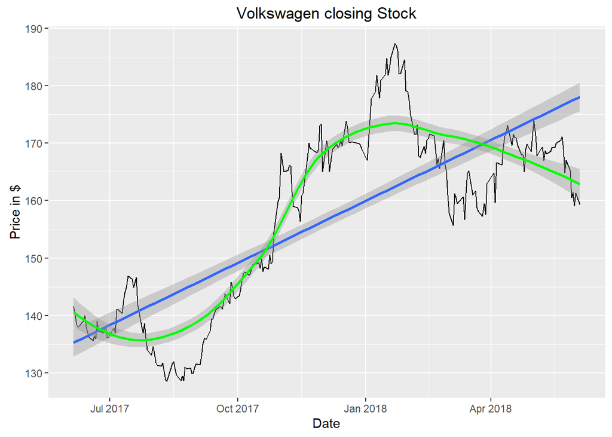

```r
volkswagen = Quandl('EURONEXT/VWA', start_date='2017-06-04', end_date='2018-06-04')
ggplot(volkswagen, aes(Date, Last,)) + geom_line() + geom_smooth(method = "lm") + geom_smooth(method = "loess", color="Green") + labs(title="Volkswagen closing Stock", y="Price in $", caption="Source: EURONEXT")
```

#### Brownian Motion

```r
nSim = 1000
nDays = 250
S0 = head(Quandl('EURONEXT/VWA', start_date='2017-06-04', end_date='2018-06-04'), n=1)
S0 = S0$Last
S = matrix(0,nrow=nDays,ncol=nSim)
```

```r
for (i in 1:nSim) {
  SVec = rep(0, nDays)
  SVec[1] = S0
  for(j in 2:nDays) {
    pastDay = SVec[j-1]
    DeltaS = volkswagenmean*pastDay + volkswagensd*pastDay*rnorm(1)
    SVec[j] = pastDay+DeltaS
  }
  S[,i] = SVec
}
```

Calculation of SimulationS bOundaries

```r
mean = volkswagenmean * nDays
sigma = volkswagensd * sqrt(nDays)
t = seq(from=0,to=1,length.out=nDays)
meanBnd = vector(length = nDays); upBnd = vector(length = nDays); loBnd = vector(length = nDays); test = vector(length = nDays)
for(i in 0:nDays){
  meanBnd[i] = S0*exp((( mean-sigma^2/2 ))*t[i])
  upBnd[i] = S0*exp((( mean-sigma^2/2 ))*t[i] + (sigma * 2.5 * sqrt(t[i])))
  loBnd[i] = S0*exp((( mean-sigma^2/2 ))*t[i] + (sigma * -2.5 * sqrt(t[i])))
}
```

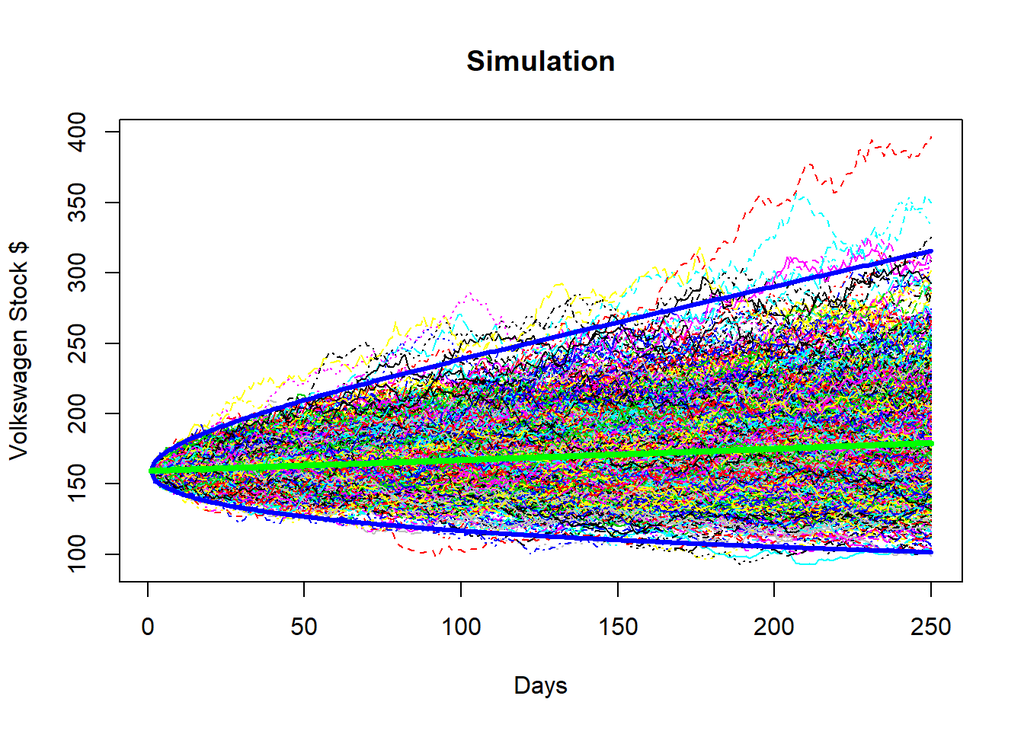

```r
matplot(S,type='l',col=1:100,ylab='Volkswagen Stock $',xlab='Days',main='Simulation')
matlines(loBnd,lwd=3,col="blue")
matlines(upBnd,lwd=3,col="blue")
matlines(meanBnd,lwd=4,col="green")
```

Calculation of the Longnormal Distribution

```r
lnMean = S0*exp(volkswagenmean*nDays)
lnSD = S0*exp(volkswagenmean*nDays)*sqrt(exp((volkswagensd^2)*nDays)-1)
```

Mean over a year over all Simulations

```r
cat('Mean',mean(S[nDays,]))
```

```
## Mean 183.8779
```

Standard deviation over a year over all Simulations

```r
cat('Standard Deviation',lnSD,sd(S[nDays,]))
```

```
## Standard Deviation 42.24418 40.52513
```

Presentation of the longnormal distribution of theoretical density and empirical density

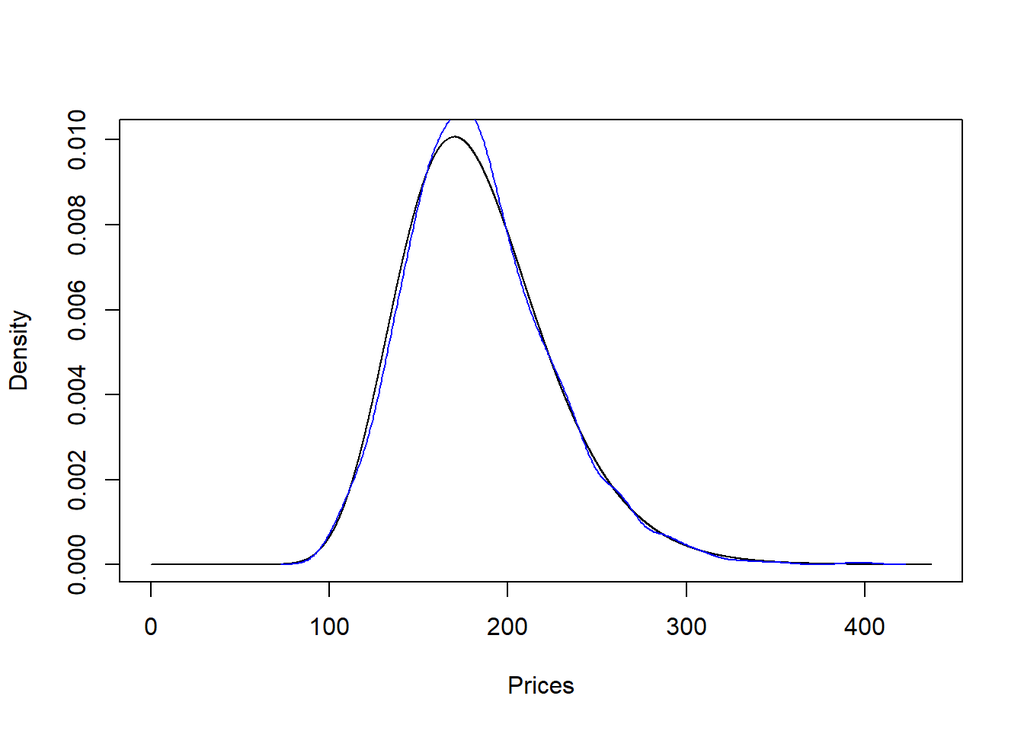

```r
meanOfLog = log(S0) + (volkswagenmean-(volkswagensd^2)/2)*nDays
sdOfLog = volkswagensd*sqrt(nDays)
priceGrid = seq(0,lnMean+6*lnSD,length=10000)
theoreticalDens = dlnorm(priceGrid,meanOfLog,sdOfLog)
empiricalDens = density(S[nDays,])

plot(priceGrid,theoreticalDens,type='l',xlab='Prices',ylab='Density')
lines(empiricalDens,col='blue')
```

### Airbus

#### Percentual rates

In this graph we can see the percentual daily rates over a year.

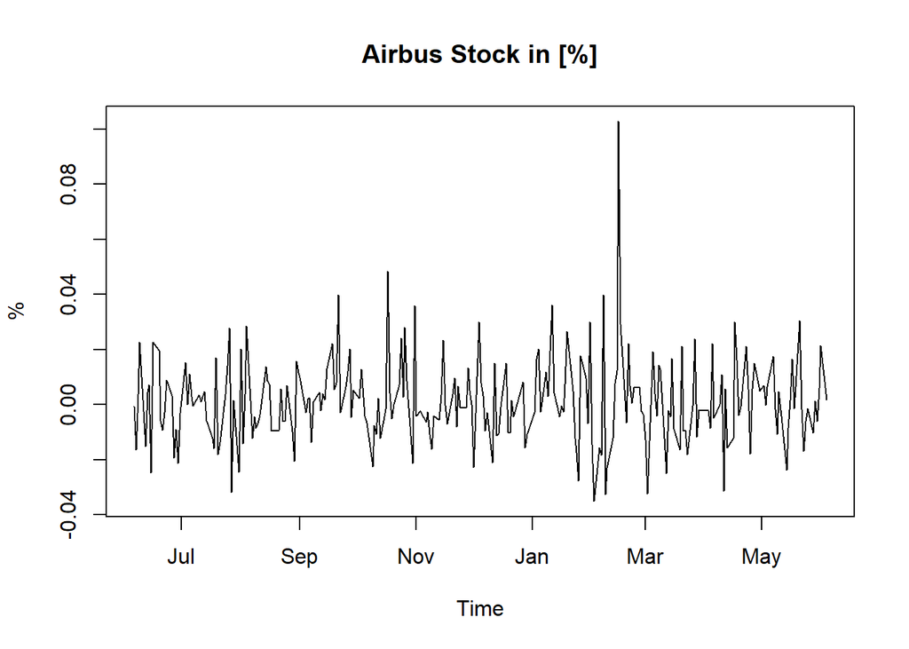

```r
Airbusclosing = Quandl('EURONEXT/AIR',start_date='2017-06-04', type='zoo',end_date='2018-06-04',transform = "rdiff")[,"Last"]
plot(Airbusclosing,ylab="%",xlab="Time",main="Airbus Stock in [%]")
```

```r
Airbussd = sd(Airbusclosing)
Airbusmean = mean(Airbusclosing)
```

#### Arithmetic mean and standard deviation

```r
Airbusmatrix = matrix(c(Airbussd,Airbusmean),ncol=2,byrow=TRUE)
colnames(Airbusmatrix) = c("Standard deviation","mean")
print.table(Airbusmatrix)
```

```
##      Standard deviation        mean
## [1,]        0.015693199 0.001258491
```

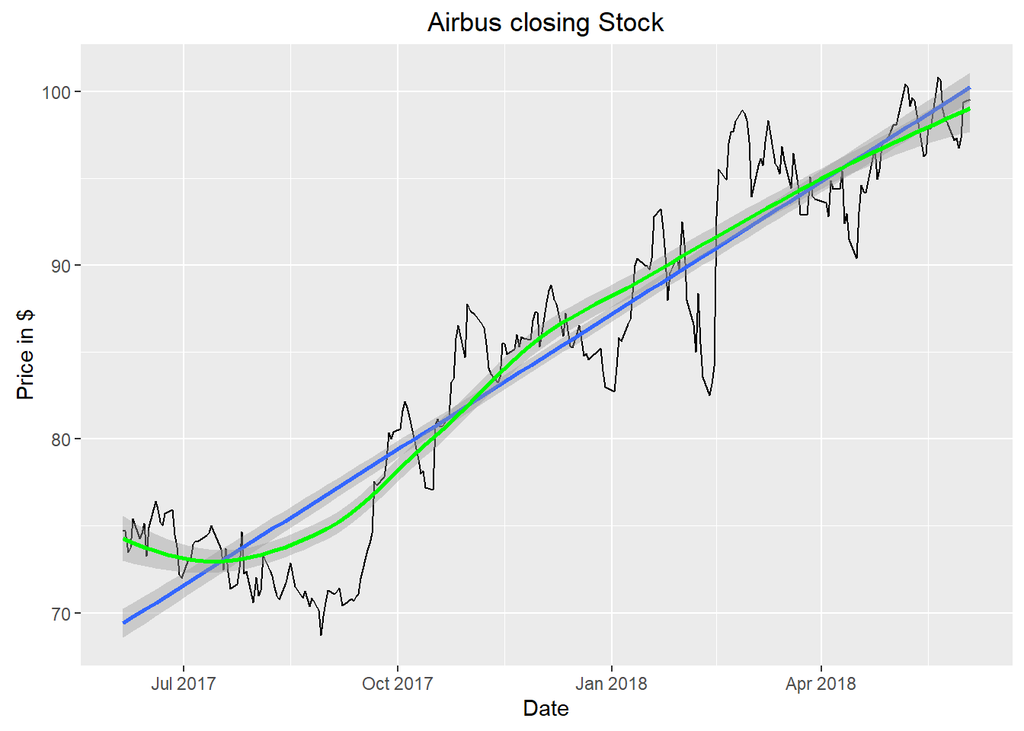

```r
Airbus = Quandl('EURONEXT/AIR', start_date='2017-06-04', end_date='2018-06-04')
ggplot(Airbus, aes(Date, Last,)) + geom_line() + geom_smooth(method = "lm") + geom_smooth(method = "loess", color="Green") + labs(title="Airbus closing Stock", y="Price in $", caption="Source: EURONEXT")
```

#### Brownian Motion

```r
nSim = 1000
nDays = 250
S0 = head(Quandl('EURONEXT/AIR', start_date='2017-06-04', end_date='2018-06-04'), n=1)
S0 = S0$Last
S = matrix(0,nrow=nDays,ncol=nSim)
```

```r
for (i in 1:nSim) {
  SVec = rep(0, nDays)
  SVec[1] = S0
  for(j in 2:nDays) {
    pastDay = SVec[j-1]
    DeltaS = Airbusmean*pastDay + Airbussd*pastDay*rnorm(1)
    SVec[j] = pastDay+DeltaS
  }
  S[,i] = SVec
}
```

Calculation of SimulationS bOundaries

```r
mean = Airbusmean * nDays
sigma = Airbussd * sqrt(nDays)
t = seq(from=0,to=1,length.out=nDays)
meanBnd = vector(length = nDays); upBnd = vector(length = nDays); loBnd = vector(length = nDays); test = vector(length = nDays)
for(i in 0:nDays){
  meanBnd[i] = S0*exp((( mean-sigma^2/2 ))*t[i])
  upBnd[i] = S0*exp((( mean-sigma^2/2 ))*t[i] + (sigma * 2.5 * sqrt(t[i])))
  loBnd[i] = S0*exp((( mean-sigma^2/2 ))*t[i] + (sigma * -2.5 * sqrt(t[i])))
}
```

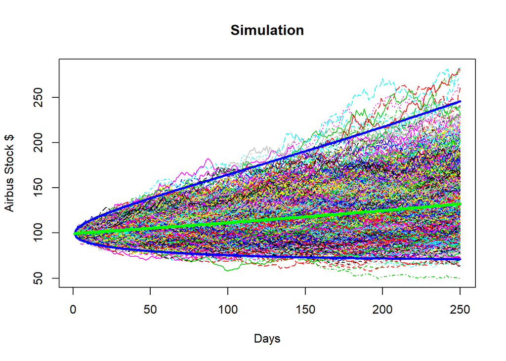

```r
matplot(S,type='l',col=1:100,ylab='Airbus Stock $',xlab='Days',main='Simulation')
matlines(loBnd,lwd=3,col="blue")
matlines(upBnd,lwd=3,col="blue")
matlines(meanBnd,lwd=4,col="green")
```

Calculation of the Longnormal Distribution

```r
lnMean = S0*exp(Airbusmean*nDays)
lnSD = S0*exp(Airbusmean*nDays)*sqrt(exp((Airbussd^2)*nDays)-1)
```

Mean over a year over all Simulations

```r
cat('Mean',mean(S[nDays,]))
```

```
## Mean 136.1382
```

Standard deviation over a year over all Simulations

```r
cat('Standard Deviation',lnSD,sd(S[nDays,]))
```

```
## Standard Deviation 34.36564 35.15018
```

Presentation of the longnormal distribution of theoretical density and empirical density

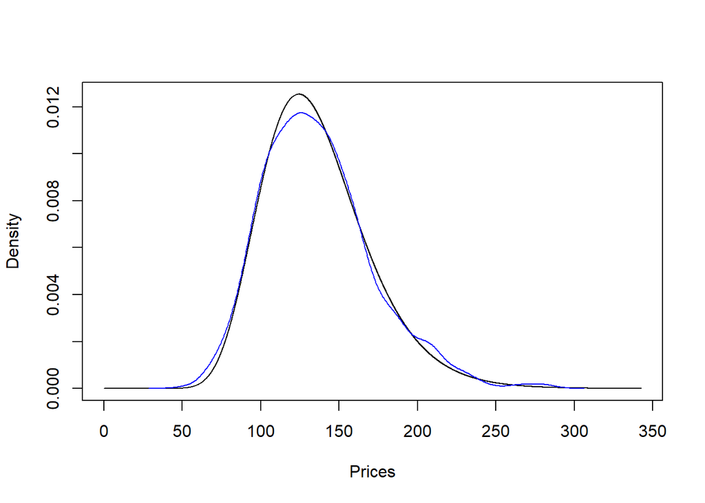

```r
meanOfLog = log(S0) + (Airbusmean-(Airbussd^2)/2)*nDays
sdOfLog = Airbussd*sqrt(nDays)
priceGrid = seq(0,lnMean+6*lnSD,length=10000)
theoreticalDens = dlnorm(priceGrid,meanOfLog,sdOfLog)
empiricalDens = density(S[nDays,])

plot(priceGrid,theoreticalDens,type='l',xlab='Prices',ylab='Density')
lines(empiricalDens,col='blue')
```